# Bike Case Study

LKGibb

2022-09-29

# SCENARIO

You are a junior data analyst working in the marketing analyst team at Cyclistic, a bike-share company in Chicago. The director of marketing believes the company’s future success depends on maximizing the number of annual memberships. Therefore, your team wants to understand how casual riders and annual members use Cyclistic bikes differently. From these insights, your team will design a new marketing strategy to convert casual riders into annual members. But first, Cyclistic executives must approve your recommendations, so they must be backed up with compelling data insights and professional data visualizations. You have been tasked with answering the following question:

### **How do annual members and casual riders use Cyclistic bikes differently?**

# Preparation

The data was downloaded from [here](https://divvy-tripdata.s3.amazonaws.com/index.html), under this [licensing](https://ride.divvybikes.com/data-license-agreement).It is stored in an AWS server, where the files are organized by individual months, as well as quarters. The data is generated by the company, ensuring originality and reliability. It is current and comprehensive. I began by downloading the most recent full year of data, storing them locally for my use.

# Process

I initially loaded the data in Excel,using UNIQUE and VLOOKUP to create a master list of station names and id’s to try to fill in some blanks in the data . However, when trying to merge the files into one, the resulting workbook was far too large to work with and generated errors that crippled the functionality of Excel, so I tried R.

### Begin by loading and installing the necessary packages

```r
install.packages("dplyr",repos = "http://cran.us.r-project.org")

install.packages("tidyverse",repos = "http://cran.us.r-project.org")

install.packages("lubridate",repos = "http://cran.us.r-project.org")

install.packages("readr",repos = "http://cran.us.r-project.org")

install.packages("shiny",repos = "http://cran.us.r-project.org")

library(dplyr)

library(tidyverse)

library(lubridate)

library(readr)

library(shiny)
```

### Load the CSV files

```r
tripdata202109 <- read_csv("~/CaseStudy1/2021/202109-divvy-tripdata.csv")
tripdata202110 <- read_csv("~/CaseStudy1/2021/202110-divvy-tripdata.csv")
tripdata202111 <- read_csv("~/CaseStudy1/2021/202111-divvy-tripdata.csv")
tripdata202112 <- read_csv("~/CaseStudy1/2021/202112-divvy-tripdata.csv")
tripdata202101 <- read_csv("~/CaseStudy1/2021/202101-divvy-tripdata.csv")
tripdata202102 <- read_csv("~/CaseStudy1/2021/202102-divvy-tripdata.csv")
tripdata202103 <- read_csv("~/CaseStudy1/2021/202103-divvy-tripdata.csv")
tripdata202104 <- read_csv("~/CaseStudy1/2021/202104-divvy-tripdata.csv")
tripdata202105 <- read_csv("~/CaseStudy1/2021/202105-divvy-tripdata.csv")
tripdata202106 <- read_csv("~/CaseStudy1/2021/202106-divvy-tripdata.csv")
tripdata202107 <- read_csv("~/CaseStudy1/2021/202107-divvy-tripdata.csv")
tripdata202108 <- read_csv("~/CaseStudy1/2021/202108-divvy-tripdata.csv")
```

### Consolidate the data

Before merging the data into a single file, I must make sure the files each have the same columns.

```r
colnames(tripdata202109)
```

```
##  [1] "ride_id"            "rideable_type"      "started_at"
##  [4] "ended_at"           "start_station_name" "start_station_id"
##  [7] "end_station_name"   "end_station_id"     "start_lat"
## [10] "start_lng"          "end_lat"            "end_lng"
## [13] "member_casual"
```

```r
colnames(tripdata202110)
```

```
##  [1] "ride_id"            "rideable_type"      "started_at"
##  [4] "ended_at"           "start_station_name" "start_station_id"
##  [7] "end_station_name"   "end_station_id"     "start_lat"
## [10] "start_lng"          "end_lat"            "end_lng"
## [13] "member_casual"
```

```r
colnames(tripdata202111)
```

```
##  [1] "ride_id"            "rideable_type"      "started_at"
##  [4] "ended_at"           "start_station_name" "start_station_id"
##  [7] "end_station_name"   "end_station_id"     "start_lat"
## [10] "start_lng"          "end_lat"            "end_lng"
## [13] "member_casual"
```

```r
colnames(tripdata202112)
```

```
##  [1] "ride_id"            "rideable_type"      "started_at"
##  [4] "ended_at"           "start_station_name" "start_station_id"
##  [7] "end_station_name"   "end_station_id"     "start_lat"
## [10] "start_lng"          "end_lat"            "end_lng"
## [13] "member_casual"
```

```r
colnames(tripdata202101)
```

```
##  [1] "ride_id"            "rideable_type"      "started_at"
##  [4] "ended_at"           "start_station_name" "start_station_id"
##  [7] "end_station_name"   "end_station_id"     "start_lat"
## [10] "start_lng"          "end_lat"            "end_lng"
## [13] "member_casual"
```

```r
colnames(tripdata202102)
```

```
##  [1] "ride_id"            "rideable_type"      "started_at"
##  [4] "ended_at"           "start_station_name" "start_station_id"
##  [7] "end_station_name"   "end_station_id"     "start_lat"
## [10] "start_lng"          "end_lat"            "end_lng"
## [13] "member_casual"
```

```r
colnames(tripdata202103)
```

```
##  [1] "ride_id"            "rideable_type"      "started_at"
##  [4] "ended_at"           "start_station_name" "start_station_id"
##  [7] "end_station_name"   "end_station_id"     "start_lat"
## [10] "start_lng"          "end_lat"            "end_lng"
## [13] "member_casual"
```

```r
colnames(tripdata202104)
```

```
##  [1] "ride_id"            "rideable_type"      "started_at"
##  [4] "ended_at"           "start_station_name" "start_station_id"
##  [7] "end_station_name"   "end_station_id"     "start_lat"
## [10] "start_lng"          "end_lat"            "end_lng"
## [13] "member_casual"
```

```r
colnames(tripdata202105)
```

```
##  [1] "ride_id"            "rideable_type"      "started_at"
##  [4] "ended_at"           "start_station_name" "start_station_id"
##  [7] "end_station_name"   "end_station_id"     "start_lat"
## [10] "start_lng"          "end_lat"            "end_lng"
## [13] "member_casual"
```

```r
colnames(tripdata202106)
```

```
##  [1] "ride_id"            "rideable_type"      "started_at"
##  [4] "ended_at"           "start_station_name" "start_station_id"
##  [7] "end_station_name"   "end_station_id"     "start_lat"
## [10] "start_lng"          "end_lat"            "end_lng"
## [13] "member_casual"
```

```r
colnames(tripdata202107)
```

```
##  [1] "ride_id"            "rideable_type"      "started_at"
##  [4] "ended_at"           "start_station_name" "start_station_id"
##  [7] "end_station_name"   "end_station_id"     "start_lat"
## [10] "start_lng"          "end_lat"            "end_lng"
## [13] "member_casual"
```

```r
colnames(tripdata202108)
```

```
##  [1] "ride_id"            "rideable_type"      "started_at"
##  [4] "ended_at"           "start_station_name" "start_station_id"
##  [7] "end_station_name"   "end_station_id"     "start_lat"
## [10] "start_lng"          "end_lat"            "end_lng"
## [13] "member_casual"
```

All the columns are the same, so we can proceed merging all the data into a single CSV file.

```r
setwd("~/CaseStudy1/2021")
df <- list.files(path="C:/Users/Linds/Documents/CaseStudy1/2021", full.names = TRUE) %>%
  lapply(read_csv) %>%
  bind_rows
write.csv(df,'alltripdata01.csv', row.names=FALSE)
```

Let’s check and make sure all the columns in the new CSV file are correct.

```r
atd <- read_csv("~/CaseStudy1/2021/alltripdata01.csv")
head(atd)
```

```
## # A tibble: 6 × 13
##   ride_id        ridea…¹ started_at          ended_at            start…² start…³
##   <chr>          <chr>   <dttm>              <dttm>              <chr>   <chr>
## 1 E19E6F1B8D4C4… electr… 2021-01-23 16:14:19 2021-01-23 16:24:44 Califo… 17660
## 2 DC88F20C2C55F… electr… 2021-01-27 18:43:08 2021-01-27 18:47:12 Califo… 17660
## 3 EC45C94683FE3… electr… 2021-01-21 22:35:54 2021-01-21 22:37:14 Califo… 17660
## 4 4FA453A75AE37… electr… 2021-01-07 13:31:13 2021-01-07 13:42:55 Califo… 17660
## 5 BE5E8EB4E7263… electr… 2021-01-23 02:24:02 2021-01-23 02:24:45 Califo… 17660
## 6 5D8969F88C773… electr… 2021-01-09 14:24:07 2021-01-09 15:17:54 Califo… 17660
## # … with 7 more variables: end_station_name <chr>, end_station_id <chr>,
## #   start_lat <dbl>, start_lng <dbl>, end_lat <dbl>, end_lng <dbl>,
## #   member_casual <chr>, and abbreviated variable names ¹rideable_type,
## #   ²start_station_name, ³start_station_id
```

### Add new column with the day of the week the trip began

```r
atd <- dplyr::mutate(atd, day_of_week=weekdays(started_at), .before = "started_at")
head(atd)
```

```
## # A tibble: 6 × 14
##   ride_id        ridea…¹ day_o…² started_at          ended_at            start…³
##   <chr>          <chr>   <chr>   <dttm>              <dttm>              <chr>
## 1 E19E6F1B8D4C4… electr… Saturd… 2021-01-23 16:14:19 2021-01-23 16:24:44 Califo…
## 2 DC88F20C2C55F… electr… Wednes… 2021-01-27 18:43:08 2021-01-27 18:47:12 Califo…
## 3 EC45C94683FE3… electr… Thursd… 2021-01-21 22:35:54 2021-01-21 22:37:14 Califo…
## 4 4FA453A75AE37… electr… Thursd… 2021-01-07 13:31:13 2021-01-07 13:42:55 Califo…
## 5 BE5E8EB4E7263… electr… Saturd… 2021-01-23 02:24:02 2021-01-23 02:24:45 Califo…
## 6 5D8969F88C773… electr… Saturd… 2021-01-09 14:24:07 2021-01-09 15:17:54 Califo…
## # … with 8 more variables: start_station_id <chr>, end_station_name <chr>,
## #   end_station_id <chr>, start_lat <dbl>, start_lng <dbl>, end_lat <dbl>,
## #   end_lng <dbl>, member_casual <chr>, and abbreviated variable names
## #   ¹rideable_type, ²day_of_week, ³start_station_name
```

### Add new column with total time per ride

```r
atd <- mutate(atd, ride_length=difftime(ended_at,started_at,units="mins"), .after = "day_of_week")
```

Let’s make sure the new column values are accurate

```r
filter(atd, ride_length <0)
```

```
## # A tibble: 294 × 15
##    ride_id       ridea…¹ day_o…² ride_…³ started_at          ended_at
##    <chr>         <chr>   <chr>   <drtn>  <dttm>              <dttm>
##  1 FC1EFEF4475D… classi… Saturd… -1.716… 2021-01-09 15:42:45 2021-01-09 15:41:02
##  2 B1235D38EB2F… electr… Wednes… -2.083… 2021-01-06 18:33:12 2021-01-06 18:31:07
##  3 F79335E3A77A… electr… Monday  -0.016… 2021-03-29 15:41:21 2021-03-29 15:41:20
##  4 5D2797A8FFA7… classi… Saturd… -0.016… 2021-03-13 18:02:58 2021-03-13 18:02:57
##  5 BC53ECCBC762… classi… Wednes… -0.116… 2021-04-07 16:11:33 2021-04-07 16:11:26
##  6 209C097828F9… electr… Tuesday -2.200… 2021-04-27 17:13:44 2021-04-27 17:11:32
##  7 6E81034B446F… electr… Friday  -0.166… 2021-04-23 09:43:39 2021-04-23 09:43:29
##  8 318DD838369A… classi… Friday  -0.033… 2021-04-30 10:56:32 2021-04-30 10:56:30
##  9 8ADD13BD8F6A… classi… Saturd… -0.150… 2021-04-17 12:43:36 2021-04-17 12:43:27
## 10 3EC1B5A4D4B9… classi… Wednes… -0.216… 2021-05-05 16:10:04 2021-05-05 16:09:51
## # … with 284 more rows, 9 more variables: start_station_name <chr>,
## #   start_station_id <chr>, end_station_name <chr>, end_station_id <chr>,
## #   start_lat <dbl>, start_lng <dbl>, end_lat <dbl>, end_lng <dbl>,
## #   member_casual <chr>, and abbreviated variable names ¹rideable_type,
## #   ²day_of_week, ³ride_length
```

We don’t want to include values that are less than 0 seconds, so we will drop these and check to make sure they’re gone.

```r
atd <- atd %>%
  filter(ride_length >0)
check<- atd%>%
  filter(ride_length <0)
head(check)
```

```
## # A tibble: 0 × 15
## # … with 15 variables: ride_id <chr>, rideable_type <chr>, day_of_week <chr>,
## #   ride_length <drtn>, started_at <dttm>, ended_at <dttm>,
## #   start_station_name <chr>, start_station_id <chr>, end_station_name <chr>,
## #   end_station_id <chr>, start_lat <dbl>, start_lng <dbl>, end_lat <dbl>,
## #   end_lng <dbl>, member_casual <chr>
```

Now that we’re sure that all the incorrect values are deleted, let’s separate the month and time out as separate columns for started_at and ended_at. This will give us some more options to drill down and find more trends.

### Add new columns with starting month, ending month, time started, and time ended

```r
atd <- mutate(atd, month_started=month(started_at), .after = "started_at")
atd <- mutate(atd, month_ended=month(ended_at), .after = "ended_at")
atd <- separate(atd,started_at, c("date_started","time_started"), sep = " ", remove = FALSE)
atd <- separate(atd,ended_at, c("date_ended","time_ended"), sep = " ", remove = FALSE)
head(atd)
```

```
## # A tibble: 6 × 21
##   ride_id    ridea…¹ day_o…² ride_…³ started_at          date_…⁴ time_…⁵ month…⁶
##   <chr>      <chr>   <chr>   <drtn>  <dttm>              <chr>   <chr>     <dbl>
## 1 E19E6F1B8… electr… Saturd… 10.416… 2021-01-23 16:14:19 2021-0… 16:14:…       1
## 2 DC88F20C2… electr… Wednes…  4.066… 2021-01-27 18:43:08 2021-0… 18:43:…       1
## 3 EC45C9468… electr… Thursd…  1.333… 2021-01-21 22:35:54 2021-0… 22:35:…       1
## 4 4FA453A75… electr… Thursd… 11.700… 2021-01-07 13:31:13 2021-0… 13:31:…       1
## 5 BE5E8EB4E… electr… Saturd…  0.716… 2021-01-23 02:24:02 2021-0… 02:24:…       1
## 6 5D8969F88… electr… Saturd… 53.783… 2021-01-09 14:24:07 2021-0… 14:24:…       1
## # … with 13 more variables: ended_at <dttm>, date_ended <chr>,
## #   time_ended <chr>, month_ended <dbl>, start_station_name <chr>,
## #   start_station_id <chr>, end_station_name <chr>, end_station_id <chr>,
## #   start_lat <dbl>, start_lng <dbl>, end_lat <dbl>, end_lng <dbl>,
## #   member_casual <chr>, and abbreviated variable names ¹rideable_type,
## #   ²day_of_week, ³ride_length, ⁴date_started, ⁵time_started, ⁶month_started
```

# Analyze

```r
casualmembertotal<- atd %>% count(member_casual,month_started, sort = TRUE)
cmtotal<- atd %>% count(member_casual, sort = TRUE)
head(cmtotal)
```

```
## # A tibble: 2 × 2
##   member_casual       n
##   <chr>           <int>
## 1 member        6131492
## 2 casual        5057328
```

### Average ride time

```r
rideavg<- mean(atd$ride_length)

cmavgridetime<- atd %>%
   group_by(member_casual, month_started) %>%
   summarise_at(vars(ride_length), list(ride_time = mean))

print(rideavg)
```

```
## Time difference of 21.93831 mins
```

```r
View(cmavgridetime)
```

Let’s break that down into separate tibbles, one for casual users and one for members.

```r
casualridetime<- filter(cmavgridetime, member_casual == "casual")

memberridetime<- filter(cmavgridetime, member_casual == "member")


View(casualridetime)
View(memberridetime)
```

Let’s find the min and max average ride time for each month, as well as the difference between them.

```r
minmember<- min(memberridetime$ride_time)
maxmember<- max(memberridetime$ride_time)
difmember<- maxmember - minmember
print(minmember)
```

```
## Time difference of 11.00568 mins
```

```r
print(maxmember)
```

```
## Time difference of 18.02345 mins
```

```r
print(difmember)
```

```
## Time difference of 7.017772 mins
```

```r
mincasual<- min(casualridetime$ride_time)
maxcasual<- max(casualridetime$ride_time)
difcasual<- maxcasual - mincasual
print(mincasual)
```

```
## Time difference of 23.13548 mins
```

```r
print(maxcasual)
```

```
## Time difference of 49.3781 mins
```

```r
print(difcasual)
```

```
## Time difference of 26.24262 mins
```

```r
minmembercasual<- mincasual - minmember
maxmembercasual<- maxcasual - maxmember
difmembercasual<- difcasual - difmember
print(minmembercasual)
```

```
## Time difference of 12.1298 mins
```

```r
print(maxmembercasual)
```

```
## Time difference of 31.35465 mins
```

```r
print(difmembercasual)
```

```
## Time difference of 19.22485 mins
```

```r
startcount<- atd %>%
  count(start_station_name, sort = TRUE)
endcount<- atd %>%
  count(end_station_name, sort = TRUE)
routecount<-  atd %>% count(start_station_name, end_station_name, sort = TRUE)
```

# Visualizations

Let’s make some of this analysis easier to spot and understand with visualizations!

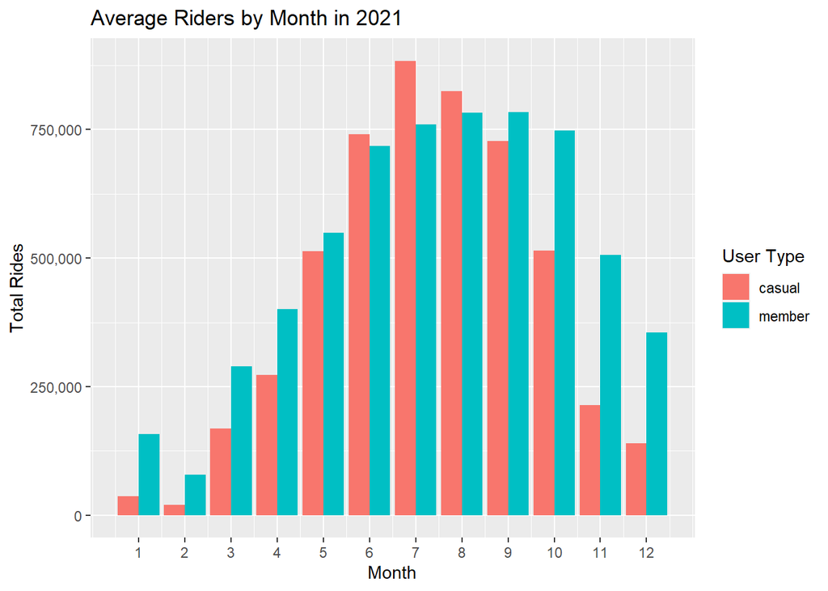

```r
p<- ggplot(data = casualmembertotal, aes(fill=member_casual, y=n, x=month_started)) +
    geom_bar(position="dodge", stat="identity")
p + ggtitle("Average Riders by Month in 2021") + scale_x_continuous(name="Month", breaks = seq(1,12,1)) + scale_y_continuous(name="Total Rides", labels = scales::comma) + labs(fill = "User Type")
```

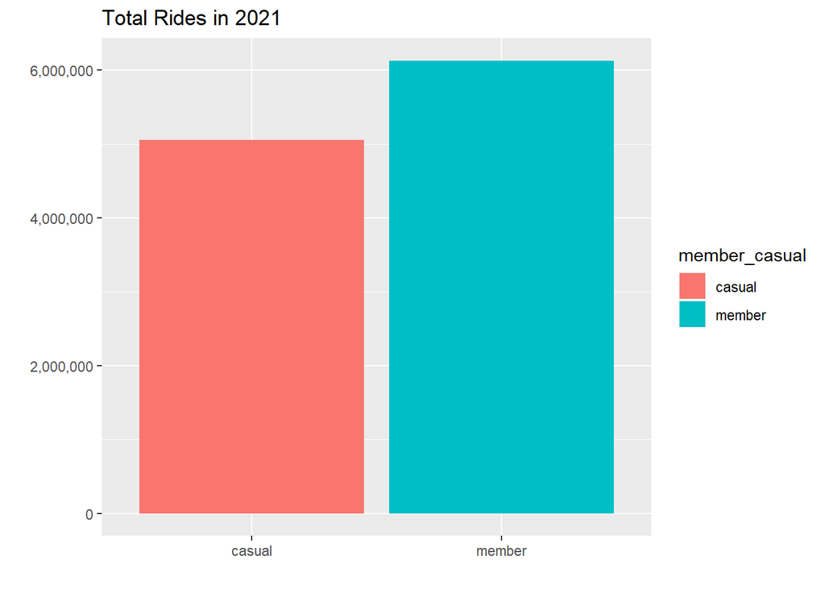

```r
p2<- ggplot (data = cmtotal) + geom_col(mapping=aes(x=member_casual, y=n, fill=member_casual))
p2 + ggtitle("Total Rides in 2021") +
  xlab("") + scale_y_continuous(name = "", labels = scales::comma)
```

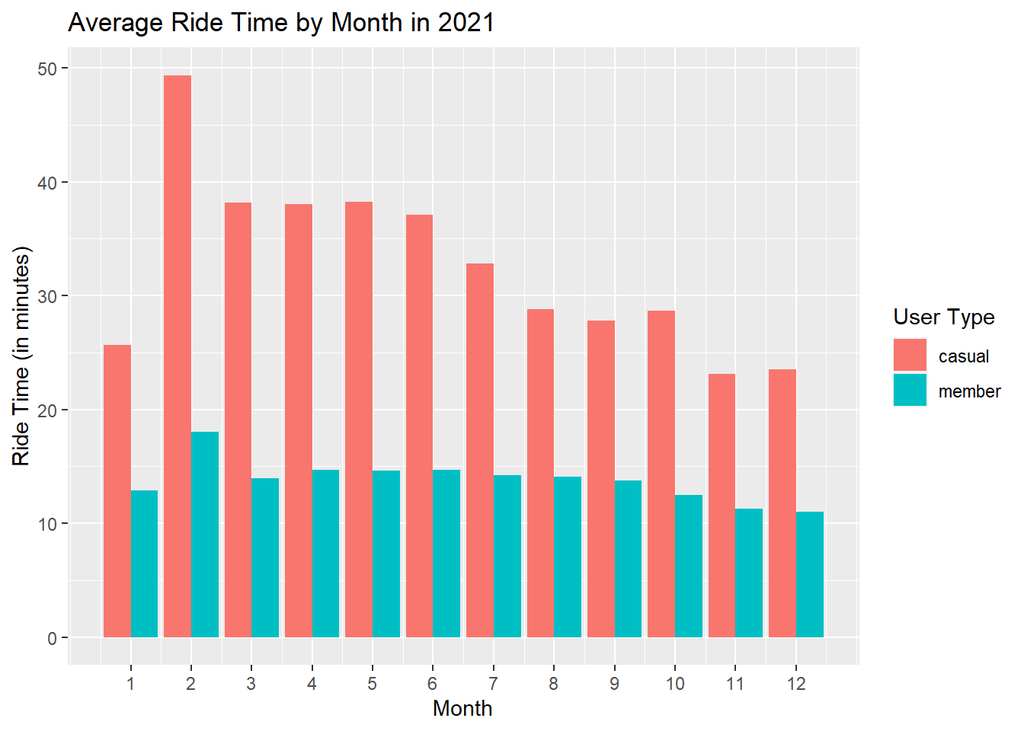

```r
p3<- ggplot(data = cmavgridetime, aes(fill=member_casual, y=ride_time, x=month_started)) +
    geom_bar(position="dodge", stat="identity")
p3 + ggtitle("Average Ride Time by Month in 2021") + scale_x_continuous(name="Month", breaks = seq(1,12,1)) + scale_y_continuous(name="Ride Time (in minutes)", labels = scales::comma) + labs(fill = "User Type")
```

### Make an updated CSV file with all the changes we’ve made so far

We’ll make one file of our atd dataframe, as well as ones for some of the other tibbles we’ve created during analysis. These can be used for further data analysis in another programming language, like SQL, as well as visualization tools, like Power BI or Tableau

```r
write.csv(atd, 'atd01.csv', row.names = FALSE)
write.csv(casualmembertotal, 'casualmembertotal.csv', row.names = FALSE)
write.csv(casualridetime, 'cridetime.csv', row.names = FALSE)
write.csv(cmavgridetime, 'cmavgridetime.csv', row.names = FALSE)
write.csv(cmtotal, 'cmtotal.csv', row.names = FALSE)
write.csv(memberridetime, 'memberridetime.csv', row.names = FALSE)
write.csv(startcount, 'startstationcount.csv', row.names = FALSE)
write.csv(endcount, 'endstationcount.csv', row.names = FALSE)
write.csv(routecount, 'routecount.csv', row.names = FALSE)
write.csv(atd, 'atd01.csv', row.names = FALSE)
```